# 191125 Expt.298: MS rRNA-specific capture by ribo-zero

**Background:** We last tested this in 190617 Expt 2-76 Hybridisation for ncRNA and rRNA. Results looked promising but were not fully analysed. This capture was done with an OdT eluate, thence the starting point was aqueous. Also, we cannot tell if the capture was non-specific because the OdT NC input control would have had no protein in it.

Thus we try to adapt the hybridisation conditions to use with ribo-zero.

**Aims:**

1. To conduct a ribo-zero capture, directly from the interphase.
2. To investigate whether the biotin-streptavidin association is disrupted by our stringent capture buffer
3. To develop bioinformatic methods for gloabl and targeted RBP identification and analysis.

# Table of Contents

## 1. Import Modules and Files

**Custom Functions**  
jwrangle.importMixedFiles( )

I generally import everything I MIGHT use at the start and set up pathing using the OS-agnostic pathlib.

```python
#### File utilities
import os
import pandas as pd
from pathlib import Path
from imp import reload

#### Data Wrangling
import copy
import numpy as np

#### RBP Suite Modules
import jwrangle
import jvis
import jinspect
import jtest
import jweb

#### Sequence Tools
from Bio import SeqIO

#### Graphical Packages
import upsetplot as upset
import seaborn as sns
import matplotlib.pyplot as plt
import altair as alt

#### define working directories
cwd  = Path(os.getcwd())
base_path = Path(os.path.join(*cwd.parts[:cwd.parts.index('experiments')]))

#### MaxQuant proteinGroups & evidence files
MQ_folder = jwrangle.importMixedFiles(cwd / 'MaxQuant')
MQ_folder.keys()

pGroups = MQ_folder['proteinGroups.txt']
evidence = MQ_folder['evidence.txt']

#### Inspect MQ setup
MQ_folder['parameters.txt'].head(9)
```

|  | Parameter | Value |
| --- | --- | --- |
| 0 | Version | 1.6.7.0 |
| 1 | User name | smith.j |
| 2 | Machine name | MSCYPHER-253 |
| 3 | Date of writing | 07/02/2020 17:55:26 |
| 4 | Include contaminants | True |
| 5 | PSM FDR | 0.01 |
| 6 | PSM FDR Crosslink | 0.01 |
| 7 | Protein FDR | 0.01 |
| 8 | Site FDR | 0.01 |

## 2. Metadata Creation

**Custom Functions**  
jwrangle.MQ_writeMetadata( )

Metadata tabulates the test conditions for ALL experiments that shared the same MQ search and thuss all experiments that comprise the MQ outputs. Metadata can also be done in a spreadsheet program. Here, I have created my metadata programmatically instead (I simply find this easier).  
The metadata table gives users the opportunity to rename samples and define the experimental parameters for the data. This task can be expecially complex for MaxQuant because a unified output is generated even if distinctly separate experiments are searched as a batch and with different parameters applied.  
The function **jwrangle.MQ_writeMetadata( )** will take a metadata table, rename all samples in the proteinGroups and evidence files, assign alternative filenames, and save new copies to be used in future analyses.

```python
#### Inspect column names
colnames = list(pGroups.columns.values)

#### Derive experiment names as a list
experiment_names = []
for i in colnames:
    if 'Intensity ' in i:
        experiment_names.append(i.replace('Intensity ', ''))

#### Fix up some of the names
mockexpt_names = []
for i in experiment_names:
    if i == 's48_rRNA1of10_Slot1-54_1_4211':
        i = 'p3833_48_PCprobe_A_Slot1-12_1_4223'
    elif i == 's49_rRNA1of10_Slot1-53_1_4210':
        i = 'p3833_49_PCprobe_B_Slot1-12_1_4223'
    i = i.replace('PC','254-')
    i = i.replace('NC', 'nCL-')
    mockexpt_names.append(i)

mockexpt_names

#### Create a list of associated conditions
condition =  []
for i in mockexpt_names:
    condition.append(i.split('_')[2])

#### Create a list of associated replicate identifiers
replicate = []
for i in mockexpt_names:
    replicate.append(i.split('_')[3])

#### Create a more reader friendly list of sample names
samples =  []
for n, l in enumerate(condition):
    samples.append(l + '_' + replicate[n])

#### The MQ_groups dictionary assigns each condition to its MQ group parameter
MQ_groups = {'bead':['nCL-bead','254-bead'],
             'probe':['nCL-probe','254-probe']}

#### We then use the condition list to create an MQ_groups list
Grp_parameters = []
for label in condition:
    for key, value in MQ_groups.items():
        if label in value:
            Grp_parameters.append(key)

expt_df = pd.DataFrame(
    {'experiment': experiment_names,
     'condition': condition,
     'replicate': replicate,
     'sample':samples,
     'measure':['Intensity']*len(samples),                  # adding this column allows our metadata file to be compatible with Proteus
     'MQgroups':Grp_parameters
    })

expt_df
```

|  | experiment | condition | replicate | sample | measure | MQgroups |
| --- | --- | --- | --- | --- | --- | --- |
| 0 | p3833_30_NCbead_A_Slot1-10_1_4234 | nCL-bead | A | nCL-bead_A | Intensity | bead |
| 1 | p3833_31_NCbead_B_Slot1-11_1_4235 | nCL-bead | B | nCL-bead_B | Intensity | bead |
| 2 | p3833_32_NCbead_C_Slot1-12_1_4236 | nCL-bead | C | nCL-bead_C | Intensity | bead |
| 3 | p3833_33_NCbead_D_Slot1-13_1_4237 | nCL-bead | D | nCL-bead_D | Intensity | bead |
| 4 | p3833_34_NCbead_E_Slot1-14_1_4238 | nCL-bead | E | nCL-bead_E | Intensity | bead |
| 5 | p3833_35_NCbead_F_Slot1-15_1_4239 | nCL-bead | F | nCL-bead_F | Intensity | bead |
| 6 | p3833_36_PCbead_A_Slot1-13_1_4226 | 254-bead | A | 254-bead_A | Intensity | bead |
| 7 | p3833_37_PCbead_B_Slot1-14_1_4227 | 254-bead | B | 254-bead_B | Intensity | bead |
| 8 | p3833_38_PCbead_C_Slot1-15_1_4228 | 254-bead | C | 254-bead_C | Intensity | bead |
| 9 | p3833_39_PCbead_D_Slot1-16_1_4229 | 254-bead | D | 254-bead_D | Intensity | bead |
| 10 | p3833_40_PCbead_E_Slot1-17_1_4230 | 254-bead | E | 254-bead_E | Intensity | bead |
| 11 | p3833_41_PCbead_F_Slot1-18_1_4231 | 254-bead | F | 254-bead_F | Intensity | bead |
| 12 | p3833_42_NCprobe_A_Slot1-14_1_4218 | nCL-probe | A | nCL-probe_A | Intensity | probe |
| 13 | p3833_43_NCprobe_B_Slot1-15_1_4219 | nCL-probe | B | nCL-probe_B | Intensity | probe |
| 14 | p3833_44_NCprobe_C_Slot1-16_1_4220 | nCL-probe | C | nCL-probe_C | Intensity | probe |
| 15 | p3833_45_NCprobe_D_Slot1-10_1_4221 | nCL-probe | D | nCL-probe_D | Intensity | probe |
| 16 | p3833_46_NCprobe_E_Slot1-11_1_4222 | nCL-probe | E | nCL-probe_E | Intensity | probe |
| 17 | p3833_47_NCprobe_F_Slot1-12_1_4223 | nCL-probe | F | nCL-probe_F | Intensity | probe |
| 18 | p3833_50_PCprobe_C_Slot1-10_1_4212 | 254-probe | C | 254-probe_C | Intensity | probe |
| 19 | p3833_51_PCprobe_D_Slot1-11_1_4213 | 254-probe | D | 254-probe_D | Intensity | probe |
| 20 | p3833_52_PCprobe_E_Slot1-12_1_4214 | 254-probe | E | 254-probe_E | Intensity | probe |
| 21 | p3833_53_PCprobe_F_Slot1-13_1_4215 | 254-probe | F | 254-probe_F | Intensity | probe |
| 22 | s48_rRNA1of10_Slot1-54_1_4211 | 254-probe | A | 254-probe_A | Intensity | probe |
| 23 | s49_rRNA1of10_Slot1-53_1_4210 | 254-probe | B | 254-probe_B | Intensity | probe |

```python
#### Write the modified proteins Groups and evidence files to a local folder
MQ_expt295 = jwrangle.MQ_writeMetadata(pGroups, evidence, expt_df, 'e298', cwd)
```

```
metadata.csv created in metadata folder
e298_proteinGroups_metalabeled.txt created in MaxQuant folder
e298_evidence_metalabeled.txt created in MaxQuant folder
```

## 3. Re-Annotate the MaxQuant pGroups with stable Gene IDs

**Functions**  
jweb.mapAnyID( )  
jwrangle.importMixedFiles( )

MaxQuant does a good job of assigning a Gene name to each protein group. Presumably these gene names come from the FASTA. However:

- Sometimes it fails to find a gene name
- Sometimes it will assign an ID that is not a gene or include out-of-place characters
- It doesn't always seem to be consistent
- If the gene name originates from the FASTA then repeating the MQ search with an updated FASTA is the only way to update the gene IDs.
- Use of a mapping service will standardise the ID conversion practices between my datasets and those of others, including RNA-Seq.

To avoid these problems we will remap the Majority protein IDs to ENTREZ gene IDs. *jweb.mapAnyID( )* will retrieve all possible genes for each protein group, and will also select a primary ID to singularly represent the group by a consistent method. This is a very flexible function, see help( ) for further explanation. From this point, the MQ 'Gene names' column will no longer be necessary. This function can also handle ID mapping to and from almost any convention.

Ensuring our proteins have a consistent gene naming strategy is essential for inter-experiment comparison and the later use of set methods. It also creates a standard that can be applied for accurately mapping RNA-Seq results and thus aid in future mapping of protein-RNA partners.

```python
#### If not already loaded, read in the metadata-adjusted files
metadata = pd.read_csv(cwd / 'metadata' / 'e298_metadata.csv', index_col = 0)
pGroups = pd.read_csv(cwd / 'MaxQuant' / 'e298_proteinGroups_metalabeled.txt', delimiter = '\t')
evidence = pd.read_csv(cwd / 'MaxQuant' / 'e298_evidence_metalabeled.txt', delimiter = '\t')
```

```python
#### Dynamically remap gene names in our proteinGroups file and save a copy
# pGroups_remap = jweb.mapAnyID_gPro(pGroups['Majority protein IDs'].tolist(), splitstr = [';', '-'], geneProductType = 'protein',
#                               gConvertOrganism = 'hsapiens', gConvertTarget = 'ENTREZGENE', writetopath = [cwd, 'pGroups_remap'], writeTargetsAsList = 'NO')
```

```python
#### If not already loaded, read in the remapped proteinGroups file
pGroups_remap = jwrangle.importMixedFiles(cwd / 'downloads' / 'pGroups_remap', dropSuffix = 'yes')
pGroups_remap.keys()
```

```
dict_keys(['id_map', 'query_map'])
```

```python
#### jwrangle.importMixedFiles() returns a dictionary where keys = files. We want the 'id_map' table created by jweb.mapAnyID_gPro().
#### We'll rename the Query column and drop duplicates so the table can be merged with our proteinGroups table.
id_map = pGroups_remap['id_map'].rename(columns={'Query': 'Majority protein IDs'}).drop_duplicates()
id_map.head(2)
```

|  | Majority protein IDs | ENTREZGENE_gPro all | ENTREZGENE_gPro primary | ENTREZGENE_gPro name | UNIPROT_gPro status |
| --- | --- | --- | --- | --- | --- |
| 0 | A0A024R4E5;Q00341;Q00341-2;H0Y394 | HDLBP;None | HDLBP | high density lipoprotein binding protein [Sour... | SWISSPROT |
| 1 | A0A087WUT0;A0A0A0MR39;Q9P2K5 | MYEF2 | MYEF2 | myelin expression factor 2 [Source:HGNC Symbol... | SWISSPROT |

```python
#### Now use merge to add these new columns to our proteinGroups table
pGroups_map = pd.merge(pGroups, id_map, on='Majority protein IDs', how='left')

#### Check the tables are merged by viewing column elements from each.
pGroups_map[id_map.columns.tolist() + ['Peptide IDs']].head(2)
```

|  | Majority protein IDs | ENTREZGENE_gPro all | ENTREZGENE_gPro primary | ENTREZGENE_gPro name | UNIPROT_gPro status | Peptide IDs |
| --- | --- | --- | --- | --- | --- | --- |
| 0 | A0A024R4E5;Q00341;Q00341-2;H0Y394 | HDLBP;None | HDLBP | high density lipoprotein binding protein [Sour... | SWISSPROT | 12;241;245;311;565;573;614;639;749;889;907;145... |
| 1 | A0A087WUT0;A0A0A0MR39;Q9P2K5 | MYEF2 | MYEF2 | myelin expression factor 2 [Source:HGNC Symbol... | SWISSPROT | 877;1321;1695;2136;2141;2471;3715;3728 |

## 4. Review Contaminants by Sample

**Functions**  
jinspect.MQ_getContaminants( )  
MQ_getContaminants_sbplot( )  
jwrangle.importMixedFiles( )

We can extract the conaminants from our proteinGroups file using **jinspect.MQ_getContaminants( )**. These extracted table will return log2(iBAQ values).  
Contaminants can then be reviewed with **_MQ_getContaminants*sbplot( )***.

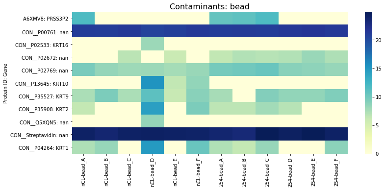

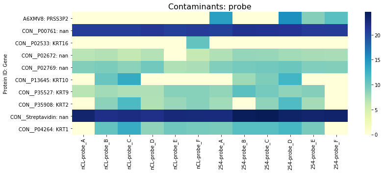

```python
#### Extract contaminants
contaminants = jinspect.MQ_getContaminants(pGroups_map, metadata)

#### Sort the metadata into a more intuitive order
metadata_sort = metadata.sort_values(by = ['MQgroups','condition', 'replicate'], ascending=[True, False, True])

#### Visually inspect contaminants
jvis.MQ_getContaminants_sbplot(contaminants, metadata_sort, width = 1, length = 2, layout = 'individual')
```

### Results: GOOD

Contaminant level is quite low and also consistent.  
Clearly the ribozero kit relies on biotin-stretavidin system.

## 5. Assess Digestion Efficiency

**Functions**  
jinspect.MQ_getMissedCleavages( )  
jvis.CommonPalettesAsHex  
jvis.BarPlotByGroup_sbplot( )

Assessing missed cleavages is an essential metric for understanding the quality of the tryptic digestion. This data is recorded in the evidence file.  
**_jinspect.MQ*getMissedCleavages( )*** will return a long form data table that can easily be used for plotting.  
The dictionary **jvis.CommonPalettesAsHex** contains a number of palettes that are common to both matplotlib and ggplot (from R). These are provided to ensure consistency is easy to achieve across both languages.  
We'll plot the missed cleavages with the generic function **jvis.BarPlotByGroup_sbplot( )**

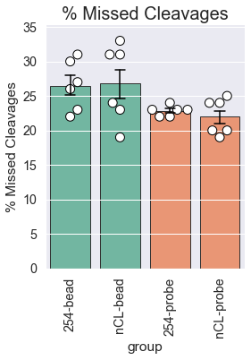

```python
#### Extract the missed cleavage data into a long form table for plotting
MissedCleavages = jinspect.MQ_getMissedCleavages(evidence, metadata_sort, drop_contaminants = True)

### Select a colour palette
cpal = jvis.CommonPalettesAsHex

set2_paired = []
for i in cpal['Set2_qual']:
    set2_paired.append(i)
    set2_paired.append(i)

#### Plot the grouped data points
sns.set_style('whitegrid')
jvis.BarPlotByGroup_sbplot(MissedCleavages, x_col = 'group', y_col = '% Missed Cleavages', title = '% Missed Cleavages', pal = set2_paired)
```

### Results: Average

Digestion efficiency isn't great. Let's reduce the digestion volume by 0.5x and maintain the same trypsin concentration in future experiments

## 6. Remove Contaminants

**Functions**  
jwrangle.MQ_getThreePassFilter( )  
SeqIO.parse( )

After QC we no longer want the contaminants in our data. **jwrangle.MQ_getThreePassFilter( )** will remove reverse peptides, contaminants, and only identified by site from MQ tables.  
The filter will also accept customised exclusion lists in case users have added odd protein species to the search FASTA tables. In this particular experiment we added to the human FASTA, RNAse proteins and the large T antigen. The former as 1) a check that dynamic range is not being overwhelmed and 2) as an quantitative spike-in control to compare tryptic efficiency and the sample recovery across samples following C18 cleanup.

```python
#### Map the location of the custom FASTA elements
os.listdir(base_path / 'my_resources' / 'FASTA')

#### Create a list of the non-human proteins that were added to the custom FASTA genome search.
new_cont = []
with open(base_path / 'my_resources' / 'FASTA' / "custom_proteome_elements.fasta", "r") as handle:
    for record in SeqIO.parse(handle, "fasta"):
        new_cont.append(record.id.split('|')[1])

#### Remove all unwanted contaminants and IDs from the proteinGroups table
pGroup_clean = jwrangle.MQ_getThreePassFilter(pGroups_map, custom_exclusion = new_cont)

#### Inspect the cleaned dataframe
pGroup_clean[['ENTREZGENE_gPro primary'] + [i for i in pGroup_clean.columns if 'iBAQ' in i]].head(2)
```

|  | ENTREZGENE_gPro primary | iBAQ | iBAQ nCL-bead_A | iBAQ nCL-bead_B | iBAQ nCL-bead_C | iBAQ nCL-bead_D | iBAQ nCL-bead_E | iBAQ nCL-bead_F | iBAQ 254-bead_A | iBAQ 254-bead_B | ... | iBAQ nCL-probe_C | iBAQ nCL-probe_D | iBAQ nCL-probe_E | iBAQ nCL-probe_F | iBAQ 254-probe_C | iBAQ 254-probe_D | iBAQ 254-probe_E | iBAQ 254-probe_F | iBAQ 254-probe_A | iBAQ 254-probe_B |
| --- | --- | --- | --- | --- | --- | --- | --- | --- | --- | --- | --- | --- | --- | --- | --- | --- | --- | --- | --- | --- | --- |
| 0 | HDLBP | 67130.0 | 0.00 | 0.00 | 0.00 | 0.0 | 0.0 | 0.00 | 0.0 | 0.0 | ... | 0.0 | 0.0 | 0.0 | 0.0 | 20303.0 | 17507.0 | 9783.1 | 10333.0 | 4283.6 | 4919.7 |
| 1 | MYEF2 | 30560.0 | 293.28 | 237.34 | 232.77 | 0.0 | 0.0 | 145.45 | 0.0 | 0.0 | ... | 0.0 | 0.0 | 0.0 | 0.0 | 6974.6 | 9791.8 | 4233.3 | 5559.2 | 2055.9 | 1036.1 |

2 rows × 26 columns

## 7. Drop Gene Duplicates and Filter Intensities by LFQ

**Functions**  
jinspect.MQ_dropDuplicateIDs( )

The next step focuses on improving confidence in the quality of our data. This is done by applying **jinspect.MQ_dropDuplicateIDs( )** which has the below effects:

- Because one gene can have many proteins, sometimes Maxquant will create multiple proteinGroups for a single gene. As most of our analysis focuses on genes we'll trim the lowest quality proteinGroups duplicates from the table.
- Standard LFQ defaults require a minimum of 2 peptide species, at least one of which must be unique, for quantitation to be applied. Intensity and iBAQ values, however, do not have such a minimum limit. I consider a 2 peptide minimum to be a wise filter but still have use for the Intensity and iBAQ values. Thus where the LFQ filter is applied all measurements that do not meet the minimum limit will be discarded. In short, if there isn't a companion LFQ value, there won't be an Intensity or iBAQ value either after filtering.
- It has been documented that Match Between Runs suffers a high frequency of false peptide transfers (Lim, Paulo, Gygi 2019; doi: 10.1021/acs.jproteome.9b00492). At the protein level, however, this false transfer rate is greatly mitigated by the minimum peptide rule applied by the LFQ algorithm. This is another good reason for our filtering step.

```python
#### Drop duplicates and apply LFQ filter
filter_dict = jinspect.MQ_dropDuplicateIDs(pGroup_clean, metadata, prefix = 'Peptides', ID = 'ENTREZGENE_gPro primary', pool = 'measure', drop_ID = 'None',
                                            keep_PoolCalcs = False, applyLFQ_filter = ['Intensity', 'iBAQ'])

#### The df_keep value contains our targets, df_droprows conatins the discarded duplicates. Assign the df_keep value to a new variable and inspect.
pGroup_filtered = filter_dict['df_keep']
pGroup_filtered.head(2)
```

```
WARNING: jinspect.MQ_getMeasuredMeansByGroup() has not been checked
```

|  | Protein IDs | Majority protein IDs | Peptide counts (all) | Peptide counts (razor+unique) | Peptide counts (unique) | Protein names | Gene names | Fasta headers | Number of proteins | Peptides | ... | iBAQ nCL-bead_C | iBAQ nCL-bead_D | iBAQ nCL-bead_E | iBAQ nCL-bead_F | iBAQ nCL-probe_A | iBAQ nCL-probe_B | iBAQ nCL-probe_C | iBAQ nCL-probe_D | iBAQ nCL-probe_E | iBAQ nCL-probe_F |
| --- | --- | --- | --- | --- | --- | --- | --- | --- | --- | --- | --- | --- | --- | --- | --- | --- | --- | --- | --- | --- | --- |
| 0 | A0A024R4E5;Q00341;Q00341-2;H0Y394;H7C0A4;C9JIZ... | A0A024R4E5;Q00341;Q00341-2;H0Y394 | 32;31;27;21;12;9;9;8;7;7;7;6;6;4;4;3;3;3;2;2;1;1 | 32;31;27;21;12;9;9;8;7;7;7;6;6;4;4;3;3;3;2;2;1;1 | 32;31;27;21;12;9;9;8;7;7;7;6;6;4;4;3;3;3;2;2;1;1 | Vigilin | HDLBP | ;;; | 22 | 32 | ... | 0.0 | 0.0 | 0.0 | 0.00 | 0.0 | 0.0 | 0.0 | 0.0 | 0.0 | 0.0 |
| 1 | A0A087WUT0;A0A0A0MR39;Q9P2K5;H0YKS1;A0A087WWC8... | A0A087WUT0;A0A0A0MR39;Q9P2K5 | 8;8;8;2;1;1 | 8;8;8;2;1;1 | 1;1;1;0;0;0 | Myelin expression factor 2 | MYEF2 | ;; | 6 | 8 | ... | 0.0 | 0.0 | 0.0 | 145.45 | 0.0 | 0.0 | 0.0 | 0.0 | 0.0 | 0.0 |

2 rows × 260 columns

## 8. Review Sample Clustering by Group

**Functions**  
jtest.getDistanceMatrix( )  
jvis.MQ_showDendrogramQC_mplplot( )

A distance matrix function **jtest.getDistanceMatrix( )** is provided for users who wish to apply different algorithms or create different visualisations.  
I like the 'ward' method for distance calculations and using a dengrogram to confirm that clustering matches expectations and so use a prerolled function **jvis.MQ_showDendrogramQC_mplplot( )**

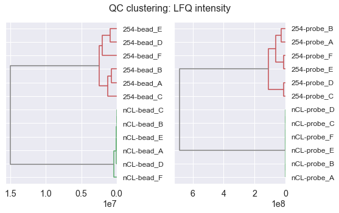

```python
#### Confirm that clustering matches expectations
jvis.MQ_showDendrogramQC_mplplot(pGroup_filtered, 'LFQ intensity', metadata, 'QC clustering: ', grid = 'YES', fsize = (8, 5))
```

### Results: GOOD

QC clustering is as expected.

## 9. Analyse Normalisation Effects by Sample

**Functions**  
jwrangle.Log2_ByPrefix( )  
jwrangle.MQ_poolMulti( )  
jvis.ViolinCompare_sbplot( )

Here we review normalisation effects on each sample within the condition groups; these are most easily interpreted after log2 transformation. We will transform all measures of interest with **_jwrangle.Log2*ByPrefix( )*** and then pool all the values of interest, by condition, with **_jwrangle.MQ*poolMulti( )***. The function **_jvis.ViolinCompare*sbplot( )*** will let use compare Intensity distribution on a per sample basis.

Normalisation is applied to LFQ values by MaxQuant and is a feature of its handling of label-free data. I've not seen a detailed explanation of how it works though so it is a leap of faith that Cox and Mann have selected an appropriate method.  
Normalisation must be applied separately to nCL and cCL groups. This is unusual though necessary to avoid outrageous results caused by having groups with extreme differences. See expt.313 for evidence.

```python
#### Log2 transform available intensity values.
pGroup_log2 = jwrangle.Log2_ByPrefix(pGroup_filtered, 'LFQ intensity')
pGroup_log2 = jwrangle.Log2_ByPrefix(pGroup_log2, 'iBAQ')
pGroup_log2 = jwrangle.Log2_ByPrefix(pGroup_log2, 'Intensity')
pGroup_log2.replace(0,np.nan, inplace=True)

#### Create a long form dataset for each desired grouping
pool_SampleIntensity = jwrangle.MQ_poolMulti(pGroup_log2, metadata_sort, melt_list = ['Intensity', 'LFQ intensity'], group = 'condition')
pool_SampleIntensity.keys()
```

```
dict_keys(['nCL-bead', '254-bead', 'nCL-probe', '254-probe'])
```

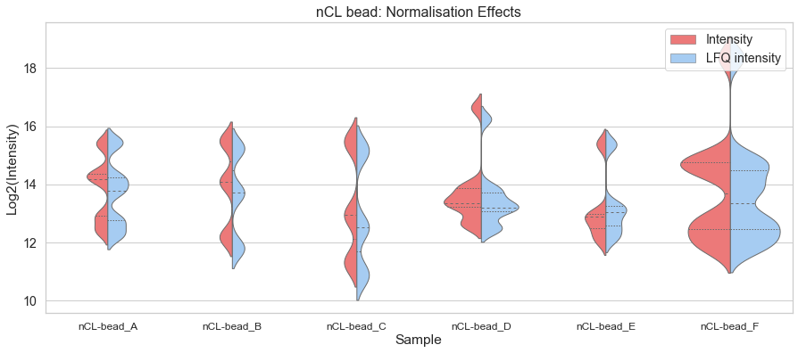

```python
#### Inspect the Intensity shifts generated by the LFQ normalisation algorithm. In MaxQuant Raw Intensity and iBAQ values are
#### not subjected to the LFQ normalisation calculations so this is a good way to spot any gross violations
sns.set_style('whitegrid')
jvis.ViolinCompare_sbplot(pool_SampleIntensity['nCL-bead'], title = 'nCL bead: Normalisation Effects', ylabel = 'Log2(Intensity)', palette = ['#ff6666', '#99ccff'])
```

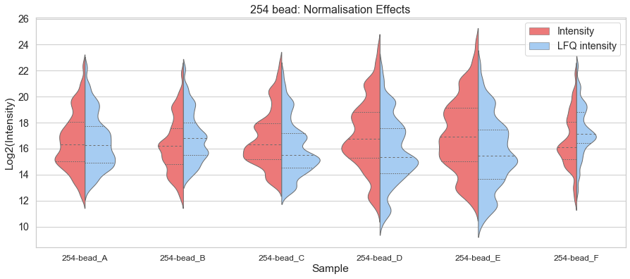

```python
sns.set_style('whitegrid')
jvis.ViolinCompare_sbplot(pool_SampleIntensity['254-bead'], title = '254 bead: Normalisation Effects', ylabel = 'Log2(Intensity)', palette = ['#ff6666', '#99ccff'])
```

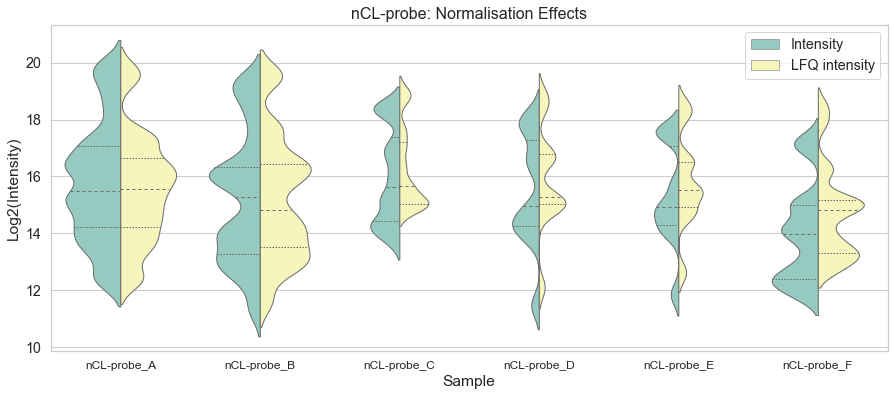

```python
jvis.ViolinCompare_sbplot(pool_SampleIntensity['nCL-probe'], title = 'nCL-probe: Normalisation Effects', ylabel = 'Log2(Intensity)', palette = cpal['Set3_qual'])
```

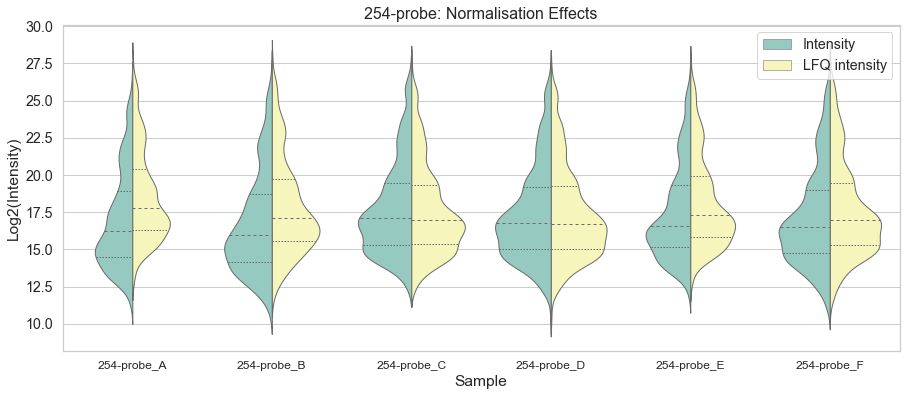

```python
jvis.ViolinCompare_sbplot(pool_SampleIntensity['254-probe'], title = '254-probe: Normalisation Effects', ylabel = 'Log2(Intensity)', palette = cpal['Set3_qual'])
```

### Result: GOOD

Obviously the nCL samples look a bit weird because there is very little in them.  
No outrageous normalisation adjustments in the cCL samples

## 10. Compare Intensity Distribution and Sequence Coverage

**Functions**  
jwrangle.MQ_poolDataByCondition( )  
jvis.BoxPlotByColumn_sbplot( )

Next we will compare intensity and sequence coverage between groups. Log2 transformation has already been performed so we need only use **jwrangle.MQ_poolDataByCondition( )** to create the appropriate long form dataset for plotting with **jvis.BoxPlotByColumn_sbplot( )**.

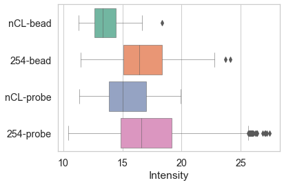

```python
#### Pool data into a single long form dataset
pooled_dfDropGroupOne = jwrangle.MQ_poolDataByCondition(pGroup_log2, metadata_sort, prefix_list = ['Intensity', 'Sequence coverage'])

#### Compare Intensity distribution using a box and whisker plot
sns.set_style('whitegrid')
jvis.BoxPlotByColumn_sbplot(pooled_dfDropGroupOne, 'Intensity: ', 'Intensity')
```

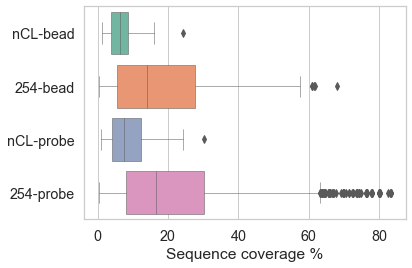

```python
#### Compare Sequence coverage using a box and whisker plot
sns.set_style('whitegrid')
jvis.BoxPlotByColumn_sbplot(pooled_dfDropGroupOne, 'Sequence coverage: ', 'Sequence coverage %')
```

### Result: GOOD

These results are consistent with expectations.

## 11. Compare Sum Peptide Counts

**Functions**  
jinspect.MQ_getSumBySample( )  
jvis.BarPlotByGroup_sbplot( )

To sum the total peptides observed across all proteins use **_jinspect.MQ*getSumBySample( )***. These sums will be returned as a modified metadata table.  
Plotting these by group is easily done with **jvis.BarPlotByGroup_sbplot( )**. The plotting order is determined by the metadata ordering.  
In this case we are inspecting the number of peptides detected after having removed contaminants- thus if some spike-in proteins were removed, i.e. in this case RNAse treatments, they will not contribute to the peptide count. To look at the replicability of these spike-ins, we would reach back to the 'df_droprows' table generated by **jinspect.MQ_dropDuplicateIDs( )** in section 7.

```python
#### Extract the total peptides observed per sample
metaStats = jinspect.MQ_getSumBySample(pGroup_log2, metadata_sort, freqList = ['Peptides'], measure = False)
metaStats
```

|  | experiment | condition | replicate | sample | measure | MQgroups | Peptides |
| --- | --- | --- | --- | --- | --- | --- | --- |
| 0 | p3833_30_NCbead_A_Slot1-10_1_4234 | nCL-bead | A | nCL-bead_A | Intensity | bead | 22.0 |
| 1 | p3833_31_NCbead_B_Slot1-11_1_4235 | nCL-bead | B | nCL-bead_B | Intensity | bead | 20.0 |
| 2 | p3833_32_NCbead_C_Slot1-12_1_4236 | nCL-bead | C | nCL-bead_C | Intensity | bead | 22.0 |
| 3 | p3833_33_NCbead_D_Slot1-13_1_4237 | nCL-bead | D | nCL-bead_D | Intensity | bead | 29.0 |
| 4 | p3833_34_NCbead_E_Slot1-14_1_4238 | nCL-bead | E | nCL-bead_E | Intensity | bead | 21.0 |
| 5 | p3833_35_NCbead_F_Slot1-15_1_4239 | nCL-bead | F | nCL-bead_F | Intensity | bead | 17.0 |
| 6 | p3833_36_PCbead_A_Slot1-13_1_4226 | 254-bead | A | 254-bead_A | Intensity | bead | 519.0 |
| 7 | p3833_37_PCbead_B_Slot1-14_1_4227 | 254-bead | B | 254-bead_B | Intensity | bead | 430.0 |
| 8 | p3833_38_PCbead_C_Slot1-15_1_4228 | 254-bead | C | 254-bead_C | Intensity | bead | 633.0 |
| 9 | p3833_39_PCbead_D_Slot1-16_1_4229 | 254-bead | D | 254-bead_D | Intensity | bead | 622.0 |
| 10 | p3833_40_PCbead_E_Slot1-17_1_4230 | 254-bead | E | 254-bead_E | Intensity | bead | 617.0 |
| 11 | p3833_41_PCbead_F_Slot1-18_1_4231 | 254-bead | F | 254-bead_F | Intensity | bead | 283.0 |
| 12 | p3833_42_NCprobe_A_Slot1-14_1_4218 | nCL-probe | A | nCL-probe_A | Intensity | probe | 101.0 |
| 13 | p3833_43_NCprobe_B_Slot1-15_1_4219 | nCL-probe | B | nCL-probe_B | Intensity | probe | 87.0 |
| 14 | p3833_44_NCprobe_C_Slot1-16_1_4220 | nCL-probe | C | nCL-probe_C | Intensity | probe | 58.0 |
| 15 | p3833_45_NCprobe_D_Slot1-10_1_4221 | nCL-probe | D | nCL-probe_D | Intensity | probe | 64.0 |
| 16 | p3833_46_NCprobe_E_Slot1-11_1_4222 | nCL-probe | E | nCL-probe_E | Intensity | probe | 45.0 |
| 17 | p3833_47_NCprobe_F_Slot1-12_1_4223 | nCL-probe | F | nCL-probe_F | Intensity | probe | 47.0 |
| 18 | s48_rRNA1of10_Slot1-54_1_4211 | 254-probe | A | 254-probe_A | Intensity | probe | 2634.0 |
| 19 | s49_rRNA1of10_Slot1-53_1_4210 | 254-probe | B | 254-probe_B | Intensity | probe | 2777.0 |
| 20 | p3833_50_PCprobe_C_Slot1-10_1_4212 | 254-probe | C | 254-probe_C | Intensity | probe | 3642.0 |
| 21 | p3833_51_PCprobe_D_Slot1-11_1_4213 | 254-probe | D | 254-probe_D | Intensity | probe | 3771.0 |
| 22 | p3833_52_PCprobe_E_Slot1-12_1_4214 | 254-probe | E | 254-probe_E | Intensity | probe | 3253.0 |
| 23 | p3833_53_PCprobe_F_Slot1-13_1_4215 | 254-probe | F | 254-probe_F | Intensity | probe | 3421.0 |

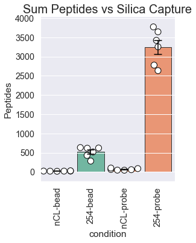

```python
#### Plot the sum peptides
sns.set_style('whitegrid')
jvis.BarPlotByGroup_sbplot(metaStats, x_col = 'condition', y_col = 'Peptides', title = 'Sum Peptides vs Silica Capture', pal = set2_paired, errorbars = 'SEM')
```

### Results: GOOD

It looks like the probe-first capture is the most efficient.

### 12. Compare Unique Gene Counts

**Functions**  
jinspect.MQ_getFrequencyBySample( )

One gene can encode for many proteins that often share regions of similarity. As for illumina-based RNA-Seq, however, shotgun proteomics can rarely assign a peptide species to a singular protein. In MaxQuant these are called proteinGroups. Because we have do not require protein-specific results, and gene identity is more stable, our gene count describes the groups to which our detected proteins have been be assigned. Thus gene here is being detected by protein product, just as it would be detected by RNA product in RNA Seq; none of these 3 are synonymous. To be clear, this is a count and not a measure.

Gene frequency is defined by the summed observations per protein regardless of intensity value and this data is extracted to our modified metadata with **jinspect.MQ_getFrequencyBySample( )** .  
A typical MQ search will yield identical protein counts (though different values) for Intensity and iBAQ*. LFQ frequencies will vary depending on the search settings:

- In this case the MQ search has set LFQ values to be calculated on a min 2 peptide ratio (this is the default)**

*Notes*  
* Why protein counts should be identical I don't know. The original iBAQ paper stipulates rules for the inclusion of a protein in the iBAQ calculation but MaxQuant doesn't seem to apply them.  
** Previously I tested LFQ min ratio at 1 peptide. At 1 minimum peptide there was unexpected QC clustering. Possible explanations for this are explained in section 7 and are cleaned up by **jinspect.MQ_dropDuplicateIDs( )** function. We can expect this function to greatly reduce qualifying IDs (~20% fewer), especially in the QE samples, but I think the trade-off is worth it because we gain 1) a more robust ID check and 2) the same search can be used for LFQ based checks of dynamic changes, i.e. comparing more than one group of cCL captures for biological changes.

```python
#### Count the number of unique
metaStats = jinspect.MQ_getFrequencyBySample(pGroup_log2, metaStats, freqList = ['Intensity', 'iBAQ', 'LFQ intensity'], measure = False)
metaStats
```

|  | experiment | condition | replicate | sample | measure | MQgroups | Peptides | Intensity | iBAQ | LFQ intensity |
| --- | --- | --- | --- | --- | --- | --- | --- | --- | --- | --- |
| 0 | p3833_30_NCbead_A_Slot1-10_1_4234 | nCL-bead | A | nCL-bead_A | Intensity | bead | 22.0 | 5 | 5 | 5 |
| 1 | p3833_31_NCbead_B_Slot1-11_1_4235 | nCL-bead | B | nCL-bead_B | Intensity | bead | 20.0 | 3 | 3 | 3 |
| 2 | p3833_32_NCbead_C_Slot1-12_1_4236 | nCL-bead | C | nCL-bead_C | Intensity | bead | 22.0 | 3 | 3 | 3 |
| 3 | p3833_33_NCbead_D_Slot1-13_1_4237 | nCL-bead | D | nCL-bead_D | Intensity | bead | 29.0 | 9 | 9 | 9 |
| 4 | p3833_34_NCbead_E_Slot1-14_1_4238 | nCL-bead | E | nCL-bead_E | Intensity | bead | 21.0 | 5 | 5 | 5 |
| 5 | p3833_35_NCbead_F_Slot1-15_1_4239 | nCL-bead | F | nCL-bead_F | Intensity | bead | 17.0 | 12 | 12 | 12 |
| 6 | p3833_36_PCbead_A_Slot1-13_1_4226 | 254-bead | A | 254-bead_A | Intensity | bead | 519.0 | 66 | 66 | 66 |
| 7 | p3833_37_PCbead_B_Slot1-14_1_4227 | 254-bead | B | 254-bead_B | Intensity | bead | 430.0 | 55 | 55 | 55 |
| 8 | p3833_38_PCbead_C_Slot1-15_1_4228 | 254-bead | C | 254-bead_C | Intensity | bead | 633.0 | 84 | 84 | 84 |
| 9 | p3833_39_PCbead_D_Slot1-16_1_4229 | 254-bead | D | 254-bead_D | Intensity | bead | 622.0 | 84 | 84 | 84 |
| 10 | p3833_40_PCbead_E_Slot1-17_1_4230 | 254-bead | E | 254-bead_E | Intensity | bead | 617.0 | 86 | 86 | 86 |
| 11 | p3833_41_PCbead_F_Slot1-18_1_4231 | 254-bead | F | 254-bead_F | Intensity | bead | 283.0 | 43 | 43 | 43 |
| 12 | p3833_42_NCprobe_A_Slot1-14_1_4218 | nCL-probe | A | nCL-probe_A | Intensity | probe | 101.0 | 23 | 23 | 23 |
| 13 | p3833_43_NCprobe_B_Slot1-15_1_4219 | nCL-probe | B | nCL-probe_B | Intensity | probe | 87.0 | 21 | 21 | 21 |
| 14 | p3833_44_NCprobe_C_Slot1-16_1_4220 | nCL-probe | C | nCL-probe_C | Intensity | probe | 58.0 | 12 | 12 | 12 |
| 15 | p3833_45_NCprobe_D_Slot1-10_1_4221 | nCL-probe | D | nCL-probe_D | Intensity | probe | 64.0 | 11 | 11 | 11 |
| 16 | p3833_46_NCprobe_E_Slot1-11_1_4222 | nCL-probe | E | nCL-probe_E | Intensity | probe | 45.0 | 10 | 10 | 10 |
| 17 | p3833_47_NCprobe_F_Slot1-12_1_4223 | nCL-probe | F | nCL-probe_F | Intensity | probe | 47.0 | 19 | 19 | 19 |
| 18 | s48_rRNA1of10_Slot1-54_1_4211 | 254-probe | A | 254-probe_A | Intensity | probe | 2634.0 | 296 | 296 | 296 |
| 19 | s49_rRNA1of10_Slot1-53_1_4210 | 254-probe | B | 254-probe_B | Intensity | probe | 2777.0 | 376 | 376 | 376 |
| 20 | p3833_50_PCprobe_C_Slot1-10_1_4212 | 254-probe | C | 254-probe_C | Intensity | probe | 3642.0 | 422 | 422 | 422 |
| 21 | p3833_51_PCprobe_D_Slot1-11_1_4213 | 254-probe | D | 254-probe_D | Intensity | probe | 3771.0 | 440 | 440 | 440 |
| 22 | p3833_52_PCprobe_E_Slot1-12_1_4214 | 254-probe | E | 254-probe_E | Intensity | probe | 3253.0 | 353 | 353 | 353 |
| 23 | p3833_53_PCprobe_F_Slot1-13_1_4215 | 254-probe | F | 254-probe_F | Intensity | probe | 3421.0 | 404 | 404 | 404 |

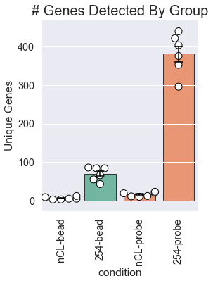

```python
#### Plot the counts
sns.set_style('whitegrid')
jvis.BarPlotByGroup_sbplot(metaStats, x_col = 'condition', y_col = 'Intensity', title = '# Genes Detected By Group', pal = set2_paired, ylabel = 'Unique Genes', errorbars = 'SEM')
```

### Results: GOOD

Again, the probe-first approach looks the most promising.

## 13. Assess Replicate Correlation

**Functions**  
jwrangle.MQ_getSliceByPrefix( )  
jvis.showPearsonRegression_altair( )

The function **_jwrangle.MQ*getSliceByPrefix( )*** provides a convenient means of extracting values of a specific group.  
We can then use **_jvis.showPearsonRegression*altair( )*** to perform pairwise comparisons between each member of those groups. This function is specifically applied to genes with shared intensities- genes exclusive to one sample or the other, represented by vertical or horizontal datapoints, are plotted but excluded from the pearson calculation.

```python
#### Extract the intensity values as a dictionary where keys = groups
Intensity_Dict = jwrangle.MQ_getSliceByPrefix(pGroup_log2, metadata, 'Intensity', group = 'condition', add_col = None)
Intensity_Dict.keys()
```

```
dict_keys(['nCL-bead', '254-bead', 'nCL-probe', '254-probe'])
```

```python
#### Check replicate consistency across all within group pairs
jvis.showPearsonRegression_altair(Intensity_Dict['254-bead'], mark_color = set2_paired[2])
jvis.showPearsonRegression_altair(Intensity_Dict['254-probe'], mark_color = set2_paired[4])
```

[interactive chart not shown]

### Results: GOOD

Replicates look good among 254nm cCL samples. nCL samples cannot be plotted due to lack of values.

## 14. Classify RBP

**Functions**  
jinspect.MQ_getFrequencyByGroup()  
jtest.MQ_applyClassifyRBP()

Before classifying our RBP we need to first tally the frequency with which each protein appears in each condition using **_jinspect.MQ*getFrequencyByGroup( )***  
Once done, we use **_jtest.MQ*applyClassifyRBP( )*** to generate a dictionary from which each class can be reviewed or plotted.

```
All proteins classified = True
All proteins classified = True
```

|  | ENTREZGENE_gPro all | ENTREZGENE_gPro primary | ENTREZGENE_gPro name | Gene names | RBP Class | RBP subClass | MQgroup |
| --- | --- | --- | --- | --- | --- | --- | --- |
| 626 | None;PA2G4 | PA2G4 | proliferation-associated 2G4 [Source:HGNC Symb... | PA2G4 | I |  | bead |

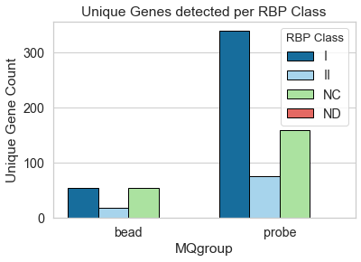

```python
#### Use the metadata and proteinGroups tables to count how many times a gene is identified in its group (/6).
#### Here I demonstrate how we can count for all instances of Intensity, iBAQ and LFQ Intensity
pGroup_Freq = jinspect.MQ_getFrequencyByGroup(pGroup_log2, metadata, 'iBAQ', group = 'condition')
pGroup_Freq = jinspect.MQ_getFrequencyByGroup(pGroup_Freq, metadata, 'LFQ intensity', group = 'condition')
pGroup_Freq = jinspect.MQ_getFrequencyByGroup(pGroup_Freq, metadata, 'Intensity', group = 'condition')

#### Now we can classify RBP; the console will report if all proteins/genes have been properly classified or not.
bead = jtest.MQ_applyClassifyRBP(pGroup_Freq, 'LFQ intensity', metadata, 'bead', 'nCL-bead', '254-bead', 3,
                                         add_cols = ['ENTREZGENE_gPro all', 'ENTREZGENE_gPro primary', 'ENTREZGENE_gPro name'])

probe = jtest.MQ_applyClassifyRBP(pGroup_Freq, 'LFQ intensity', metadata, 'probe', 'nCL-probe', '254-probe', 3,
                                         add_cols = ['ENTREZGENE_gPro all', 'ENTREZGENE_gPro primary', 'ENTREZGENE_gPro name'])



#### We want the most general overview which of our classes per treatment and so concatenate the results from each Summary_df_annStatus
RBP_Class = pd.concat([bead['Summary_df_annStatus'].sort_values(by='RBP Class'), probe['Summary_df_annStatus'].sort_values(by='RBP Class')], axis=0, join='outer')

#### And represent them in a barplot
from matplotlib import pyplot as plt

plt.figure('rbp class')
sns.set_style('whitegrid')
ax = sns.countplot(x='MQgroup', hue = 'RBP Class', data=RBP_Class, palette = cpal['RBP_Class'], edgecolor = 'black')
ax.set_ylabel('Unique Gene Count')
ax.set_title('Unique Genes detected per RBP Class')

RBP_Class.head(1)
```

|  | ENTREZGENE_gPro all | ENTREZGENE_gPro primary | ENTREZGENE_gPro name | Gene names | RBP Class | RBP subClass | MQgroup |
| --- | --- | --- | --- | --- | --- | --- | --- |
| 626 | None;PA2G4 | PA2G4 | proliferation-associated 2G4 [Source:HGNC Symb... | PA2G4 | I |  | bead |

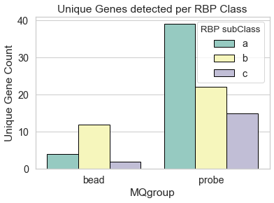

```python
#### Let's have a peek at the Class II subclass distribution
plt.figure('rbp class')
sns.set_style('whitegrid')
ax = sns.countplot(x='MQgroup', hue = 'RBP subClass', data=RBP_Class[RBP_Class['RBP subClass']!=''].sort_values(by=['MQgroup','RBP subClass']), palette = cpal['Set3_qual'], edgecolor = 'black')
ax.set_ylabel('Unique Gene Count')
ax.set_title('Unique Genes detected per RBP Class')

RBP_Class.head(1)
```

### Results: GOOD

The probe first approach has been the clear leader so far. Among the Class II Subclasses we can see most identifications can be made without calculating a fold change enrichment.

## 15. Compare RBP Identity: Silane vs rRNA

Let's compare our rRNA capture data with the silane-based global capture data we processed in another tutorial (Expt.296). This data was acquired on a far less sensitive machine, the Q-Exactive Classic, but for our purposes it should be fine, especially given the abundance of cytoplasmic rRNA and mito-rRNA in a cell. Because the silane capture is global, and the rRNA capture specific, we should expect the RBP genes identified by targeted rRNA capture to mostly fall within the global class I set.

```python
#### For baseline comparison we'll import the Class I RBPs identified from expt296 Silane Capture.
silRBP = pd.read_csv('e296_30etoh Class I RBPs.csv')
silRBP.head(1)
```

|  | Majority protein IDs | Gene names | Protein names | ENTREZGENE_gPro all | ENTREZGENE_gPro primary | ENTREZGENE_gPro name | LFQ intensity pH7-Silane-30-heat_nCL-A | LFQ intensity pH7-Silane-30-heat_nCL-B | LFQ intensity pH7-Silane-30-heat_nCL-C | LFQ intensity pH7-Silane-30-heat_nCL-D | LFQ intensity pH7-Silane-30-heat_254-A | LFQ intensity pH7-Silane-30-heat_254-B | LFQ intensity pH7-Silane-30-heat_254-C | LFQ intensity pH7-Silane-30-heat_254-D | RBP Class | RBP subClass |
| --- | --- | --- | --- | --- | --- | --- | --- | --- | --- | --- | --- | --- | --- | --- | --- | --- |
| 0 | A0A024R4E5;Q00341;Q00341-2;H0Y394 | HDLBP | Vigilin | HDLBP;None | HDLBP | high density lipoprotein binding protein [Sour... | NaN | NaN | NaN | NaN | 32.644654 | 32.545013 | 32.54077 | 32.543239 | I | NaN |

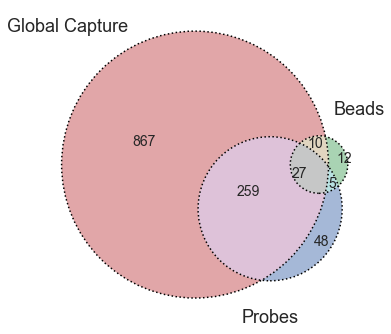

```python
#### Let's compare our rRNA capture data with the silane-based global capture data we processed in another tutorial (Expt.296).
#### This data was acquired on a far less sensitive machine, the Q-Exactive Classic, but for our purposes it should be fine, especially given the abundance of cytoplasmic rRNA and mito-rRNA in a cell.

from matplotlib import pyplot as plt
import numpy as np
from matplotlib_venn import venn3, venn3_circles

plt.figure(figsize=(6,6))

v = venn3([set(silRBP['ENTREZGENE_gPro primary']),
           set(bead['I']['ENTREZGENE_gPro primary']),
           set(probe['I']['ENTREZGENE_gPro primary'])],
           set_labels = ('Global Capture', 'Beads\n', '\nProbes'),
           alpha = 0.5)

c = venn3_circles([set(silRBP['ENTREZGENE_gPro primary']),
                   set(bead['I']['ENTREZGENE_gPro primary']),
                   set(probe['I']['ENTREZGENE_gPro primary'])], linestyle='dashed')

c[0].set_lw(1.5)
c[0].set_ls('dotted')
c[1].set_lw(1.5)
c[1].set_ls('dotted')
c[2].set_lw(1.5)
c[2].set_ls('dotted')

for text in v.set_labels:
    text.set_fontsize(18)
for text in v.subset_labels:
    text.set_fontsize(14)
```

## 16. Review Basic Gene Ontology

**Functions**  
jwrangle.importMixedFiles( )  
jweb.fetchQuickGO_stats( )

A number of GO-specific and utility functions are provided to help with retrieving Gene Ontologies from the QuickGo database. In this section we'll look at the most basic.  
The function **jweb.fetchQuickGO_stats( )** will fetch the annotation statistics for all records belonging to the gene ID from a submitted list. These statistics are generally of two types: no. of annotations (which relates to unique proteins) and no. of geneProducts (which relate to the gene count; poorly worded I know). The quality of these records is given by whether identification originates from a SwissPort or a TrEMBL entry. Reviewing these statistics before beginning an analysis is ideal, because it contextualises the breadth of future analyses. This function returns these statistics in the from of a dictionary which can be converted to a dataframe for easier viewing by using the dedicated function **jweb.getQuickGO_stats( )**.

In addition to contextualising the search space of subsequent analyses, fetching the annotation numbers is important for checking that the number of records, per GO ID, falls below 10000. This is because QuickGo will not allow larger searches to be done programmatically. If your GO ID of interest has many more records users should retrieve their records manually. These details will be covered fourther in the next section.

```python
#### I like to keep a table of interesting GO terms in a local csv file, let's find it
MyResources = jwrangle.importMixedFiles(base_path / 'my_resources')
MyResources.keys()
```

```
dict_keys(['.ipynb_checkpoints', 'control_elements', 'control_proteins', 'custom_dfs', 'FASTA', 'GOexplore.ipynb', 'GO_TermsOfInterest.csv', 'GO_TermsOfInterest_stats.csv', 'Hentze_core_RBP_list.txt', 'Hentze_core_RBP_list_uniprot.txt', 'Hentze_core_RBP_plusE1_8.txt', 'instrumentQC', 'limma_normaliz…
```

```python
MyResources['GO_TermsOfInterest.csv'].head(5)
```

|  | GO Term | relationship | depth | go ID | Description | ctrl list type | parent(s) |
| --- | --- | --- | --- | --- | --- | --- | --- |
| 0 | binding | Molecular Function | 1 | GO:0005488 | NaN | NaN | GO:0003674 |
| 1 | protein binding | Molecular Function | 2 | GO:0005515 | NaN | NaN | GO:0005488 |
| 2 | chromatin binding | Molecular Function | 2 | GO:0003682 | NaN | NaN | GO:0005488 |
| 3 | nucleic acid binding | Molecular Function | 3 | GO:0003676 | NaN | NaN | GO:0003676 |
| 4 | DNA binding | Molecular Function | 4 | GO:0003677 | NaN | general | GO:0003676 |

```python
# #### Let's get basic statistics on the all GO IDs listed from depth 3 down"
# MyGO_Stats_Dict = jweb.fetchQuickGO_stats(MyResources['GO_TermsOfInterest.csv']['go ID'].tolist()[3:], QG_geneProductType = 'protein', QG_taxonId = '9606', QG_geneProductSubset = ['Swiss-Prot', 'TrEMBL'])

# #### To view basic information, like the number of annotations associated with the GO term
# MyGO_Stats = jweb.getQuickGO_stats(MyGO_Stats_Dict)

# #### Save a local copy of the stats dataframe
# MyGO_Stats_DF = pd.merge(MyResources['GO_TermsOfInterest.csv'], MyGO_Stats, on = 'go ID', how = 'outer')
# MyGO_Stats_DF.to_csv(cwd / 'downloads' / 'MyGO_Stats_DF.csv', index = False)

# #### View the DataFrame
# MyGO_Stats_DF.head(50)
```

```python
#### Read a local copy and view DataFrame
MyGO_Stats_DF = pd.read_csv(cwd / 'downloads' / 'MyGO_Stats_DF.csv')
MyGO_Stats_DF.head(50)
```

|  | GO Term | relationship | depth | go ID | Description | ctrl list type | parent(s) | Swiss-Prot_annotations | Swiss-Prot_genesProducts | TrEMBL_annotations | TrEMBL_genesProducts |
| --- | --- | --- | --- | --- | --- | --- | --- | --- | --- | --- | --- |
| 0 | binding | Molecular Function | 1 | GO:0005488 | NaN | NaN | GO:0003674 | NaN | NaN | NaN | NaN |
| 1 | protein binding | Molecular Function | 2 | GO:0005515 | NaN | NaN | GO:0005488 | NaN | NaN | NaN | NaN |
| 2 | chromatin binding | Molecular Function | 2 | GO:0003682 | NaN | NaN | GO:0005488 | NaN | NaN | NaN | NaN |
| 3 | nucleic acid binding | Molecular Function | 3 | GO:0003676 | NaN | NaN | GO:0003676 | 15714.0 | 4127.0 | 18207.0 | 9319.0 |
| 4 | DNA binding | Molecular Function | 4 | GO:0003677 | NaN | general | GO:0003676 | 9399.0 | 2603.0 | 9854.0 | 4772.0 |
| 5 | RNA binding | Molecular Function | 4 | GO:0003723 | NaN | general | GO:0003676 | 5245.0 | 1685.0 | 4976.0 | 2620.0 |
| 6 | DNA/RNA hybrid binding | Molecular Function | 4 | GO:0071667 | NaN | general | GO:0003676 | 0.0 | 0.0 | 0.0 | 0.0 |
| 7 | translation regulator activity | Molecular Function | 4 | GO:0090079 | NaN | NaN | GO:0003676 | 359.0 | 111.0 | 673.0 | 399.0 |
| 8 | regulatory region nucleic acid binding | Molecular Function | 4 | GO:0001067 | NaN | NaN | GO:0003676 | 2866.0 | 1514.0 | 608.0 | 554.0 |
| 9 | annealing activity | Molecular Function | 4 | GO:0097617 | NaN | NaN | GO:0003676 | 21.0 | 13.0 | 7.0 | 7.0 |
| 10 | ssDNA binding | Molecular Function | 5 | GO:0003697 | NaN | general | GO:0003677 | 221.0 | 120.0 | 100.0 | 96.0 |
| 11 | dsDNA binding | Molecular Function | 5 | GO:0003690 | NaN | general | GO:0003677 | 3780.0 | 1715.0 | 826.0 | 740.0 |
| 12 | ssRNA binding | Molecular Function | 5 | GO:0003727 | NaN | general | GO:0003723 | 165.0 | 88.0 | 36.0 | 35.0 |
| 13 | dsRNA binding | Molecular Function | 5 | GO:0003725 | NaN | general | GO:0003723 | 138.0 | 79.0 | 69.0 | 68.0 |
| 14 | mRNA binding | Molecular Function | 5 | GO:0003729 | NaN | general | GO:0003723 | 573.0 | 302.0 | 277.0 | 246.0 |
| 15 | pre-mRNA binding | Molecular Function | 5 | GO:0036002 | NaN | general | GO:0003723 | 48.0 | 38.0 | 21.0 | 17.0 |
| 16 | snRNA binding | Molecular Function | 5 | GO:0017069 | NaN | general | GO:0003723 | 97.0 | 47.0 | 18.0 | 16.0 |
| 17 | rRNA binding | Molecular Function | 5 | GO:0019843 | NaN | general | GO:0003723 | 95.0 | 64.0 | 72.0 | 61.0 |
| 18 | rRNA primary transcript binding | Molecular Function | 6 | GO:0042134 | NaN | NaN | GO:0019843 | 3.0 | 1.0 | 0.0 | 0.0 |
| 19 | 5S rRNA binding | Molecular Function | 6 | GO:0008097 | NaN | NaN | GO:0019843 | 16.0 | 11.0 | 10.0 | 10.0 |
| 20 | rRNA modification guide activity | Molecular Function | 6 | GO:0030556 | NaN | NaN | GO:0019843 | 0.0 | 0.0 | 0.0 | 0.0 |
| 21 | large ribosomal subunity rRNA | Molecular Function | 6 | GO:0070180 | NaN | NaN | GO:0019843 | 5.0 | 5.0 | 0.0 | 0.0 |
| 22 | small ribosomal subunit rRNA | Molecular Function | 6 | GO:0070181 | NaN | NaN | GO:0019843 | 10.0 | 10.0 | 0.0 | 0.0 |
| 23 | B-WICH complex | Molecular Function | 6 | GO:0110016 | A chromatin remodeling complex that positively... | NaN | GO:0019843 | 0.0 | 0.0 | 0.0 | 0.0 |
| 24 | 5.8S rRNA binding | Molecular Function | 6 | GO:1990932 | NaN | NaN | GO:0019843 | 0.0 | 0.0 | 0.0 | 0.0 |
| 25 | ribosome biogenesis | Biological Process | 4 | GO:0042254 | NaN | ribozero | GO:0022613 | 909.0 | 312.0 | 460.0 | 259.0 |
| 26 | ribosome assembly | Biological Process | 5 | GO:0042255 | NaN | ribozero | GO:0042254 | 85.0 | 66.0 | 25.0 | 22.0 |
| 27 | regulation of ribosome biogenesis | Biological Process | 5 | GO:0090069 | NaN | NaN | GO:0042254 | 19.0 | 16.0 | 2.0 | 2.0 |
| 28 | positive regulation of ribosome biogenesis | Biological Process | 5 | GO:0090070 | NaN | NaN | GO:0042254 | 11.0 | 10.0 | 0.0 | 0.0 |
| 29 | negative regulation of ribosome biogenesis | Biological Process | 5 | GO:0090071 | NaN | NaN | GO:0042254 | 5.0 | 5.0 | 1.0 | 1.0 |
| 30 | ribosomal large subunit biogenesis | Biological Process | 5 | GO:0042273 | NaN | NaN | GO:0042254 | 122.0 | 74.0 | 49.0 | 29.0 |
| 31 | ribosomal small subunit biogenesis | Biological Process | 5 | GO:0042274 | NaN | NaN | GO:0042254 | 124.0 | 73.0 | 18.0 | 17.0 |
| 32 | rRNA export from the nucleus | Biological Process | 5 | GO:0006407 | NaN | NaN | GO:0042254 | 2.0 | 2.0 | 0.0 | 0.0 |
| 33 | ribosomal subunit export from nucleus | Biological Process | 5 | GO:0000054 | NaN | NaN | GO:0042254 | 27.0 | 14.0 | 23.0 | 12.0 |
| 34 | rRNA processing | Biological Process | 5 | GO:0006364 | NaN | NaN | GO:0042254 | 590.0 | 227.0 | 254.0 | 152.0 |
| 35 | ribosome disassembly | Biological Process | 5 | GO:0032790 | NaN | NaN | GO:1903008 | 12.0 | 8.0 | 4.0 | 2.0 |
| 36 | ribosome localization | Biological Process | 4 | GO:0033750 | NaN | ribozero | GO:0008104;GO:0051640 | 27.0 | 14.0 | 23.0 | 12.0 |
| 37 | mitochondrial ribosome assembly | Biological Process | 6 | GO:0061668 | NaN | ribozero | GO:0042254 | 8.0 | 6.0 | 0.0 | 0.0 |
| 38 | mitochondrial ribosome | Cellular Component | 10 | GO:0005761 | NaN | ribozero | GO:000313;GO:0005759 | 251.0 | 88.0 | 26.0 | 25.0 |
| 39 | ribosome | Cellular Component | 8 | GO:0005840 | NaN | ribozero | GO:0043232 | 1400.0 | 234.0 | 1911.0 | 713.0 |
| 40 | polysomal ribosome | Cellular Component | 9 | GO:0042788 | NaN | NaN | GO:0005840 | 35.0 | 33.0 | 3.0 | 3.0 |
| 41 | organellar ribosome | Cellular Component | 9 | GO:0000313 | NaN | NaN | GO:0005840 | 251.0 | 88.0 | 26.0 | 25.0 |
| 42 | cytosolic ribosome | Cellular Component | 9 | GO:0022626 | NaN | NaN | GO:0005840 | 295.0 | 112.0 | 31.0 | 31.0 |
| 43 | structural constituent of ribosome | Cellular Component | 9 | GO:0003735 | NaN | NaN | GO:0005840 | 411.0 | 165.0 | 608.0 | 580.0 |
| 44 | ribosomal subunit | Cellular Component | 9 | GO:0044391 | NaN | NaN | GO:0005840 | 555.0 | 190.0 | 138.0 | 135.0 |
| 45 | RQC complex | Cellular Component | 2 | GO:1990112 | A multiprotein complex that forms a stable com... | ribozero | GO:0032991 | 3.0 | 2.0 | 6.0 | 3.0 |
| 46 | ribonucleoprotein complex binding | Molecular Function | 3 | GO:0043021 | NaN | ribozero | GO:0044877 | 196.0 | 135.0 | 84.0 | 78.0 |
| 47 | ribosome binding | Molecular Function | 4 | GO:0043022 | NaN | ribozero | GO:0043021 | 81.0 | 60.0 | 47.0 | 43.0 |
| 48 | mitochondrial ribosome binding | Molecular Function | 5 | GO:0097177 | NaN | ribozero | GO:0043022 | 6.0 | 5.0 | 0.0 | 0.0 |
| 49 | mitochondrion | Cellular Component | 5 | GO:0005739 | NaN | NaN | GO:0043231;GO:0005737 | 10259.0 | 1677.0 | 34454.0 | 13352.0 |

### Results: GOOD

We can see that, with the exception of dsDNA binding, the population of members belonging to RNA-binding at depth 5 is quite sparse, especially compared to the depth 4 RNA binding category. mRNA-binding is by far the most populated group, most likely due to influences from previous OdT captures. I would expect, however, that annotations with experimental evidence are likely to be dramatically low- a good indication of the nascent state of RNA-binding protein research and one that should probably be emphasised in a future introduction.

## 17. Retrieve GO Records

**Functions**  
jweb.fetchQuickGO( )  
jwrangle.concatGO_DataFrameDict( )  
jweb.mapQuickGO( )

*A Note on Manual Downloads*  
The **jweb.fetchQuickGO( )** will also output to console the html address that one should use if a manual download if required; this address will encompass all the relevant record characteristics that typically used by this suite. Once this table has been downloaded, the function **jweb.mapQuickGO( )** can be used to provide the same ID mapping service as performed in **jweb.fetchQuickGO( )**. The returned elements will also be manipulated into the same format.

```python
#### Download and create a local copy of all the records associated with our GO query from depth 4 onwards.
# QuickGo_dict = jweb.fetchQuickGO(MyGO_Stats_DF['go ID'][4:], QG_geneProductType = 'protein', QG_taxonId = '9606', QG_geneProductSubset = ['Swiss-Prot', 'TrEMBL'], gConvertOrganism='hsapiens', writetopath= True)
```

```python
#### To avoid future API requests we will load the saved files....
QuickGo_dict = jwrangle.importMixedFiles(cwd / 'downloads' / 'QuickGo')

#### ....and concatenate all SwissProt and TrEMBL entries into a single dictionary.
QuickGo_dict_concat = jwrangle.concatGO_DataFrameDict(QuickGo_dict)
QuickGo_dict_concat.keys()
```

```
dict_keys(['GO0000054', 'GO0000313', 'GO0001067', 'GO0003677', 'GO0003690', 'GO0003697', 'GO0003723', 'GO0003725', 'GO0003727', 'GO0003729', 'GO0003735', 'GO0005739', 'GO0005761', 'GO0005840', 'GO0006364', 'GO0006407', 'GO0008097', 'GO0017069', 'GO0019843', 'GO0022626', 'GO0030556', 'GO0032790', 'GO…
```

### Results: GOOD

All records sucessfully retrieved, saved locally, and a dictionary of concatenated SwissProt and TrEMBL entries has been generated.

## 18. Analyse GO Memberships #1: RNA-binding

**Functions**  
jwrangle.AnnotateDataFrameCtrls( )  
jinspect.MQ_getFrequencyBySample( )

The function **jwrangle.AnnotateDataFrameCtrls( )** takes our QuickGo records and annotates each protein or gene in a given dataframe (i.e. a proteinGroups table) for membership to the searched GO ID. The function **jinspect.MQ_getFrequencyBySample( )** acts similarly to the peptide and gene count functions used earlier- it will sum the frequency of memberships to each GO catgeory and report the counts as a modified metadata table.

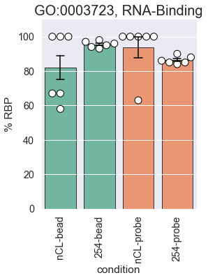

```python
#### With our GO records in hand we next investigate whether our identified proteins are members of our GO IDs
#### Let's start by looking at only GO:0003723. First, dedicate a dictionary to this search
dict_GO0003723 = {'GO0003723': QuickGo_dict_concat['GO0003723']}

#### Next, annotate the last version of our modified proteinGroups table
pGroup_GO0003723 = jwrangle.AnnotateDataFrameCtrls(pGroup_Freq, dict_GO0003723, search_match = 'ENTREZGENE_gPro primary', dict_match = 'ENTREZGENE_gPro primary', none_col = 'GO_None')

#### Next find the counts for each GO ID being searched we will modify our metadata table in a fashion in the same way as for prptide and gene counting.
#### We'll use iBAQ for these counts but, given all intensities have previously been filtered by LFQ membership both 'Intensity' or 'LFQ intensity' would give the same result.
metaStatsGO0003723 = jinspect.MQ_getFrequencyBySample(pGroup_GO0003723['ann_df'], metaStats, freqList = list(dict_GO0003723.keys()) + ['GO_None'], measure = 'iBAQ')

#### Now Calculate the % GO0003723 members per group
metaStatsGO0003723['% RBP'] = metaStatsGO0003723.apply(lambda row: round(100*row['GO0003723']/(row['GO0003723']+row['GO_None'])), axis = 1)

#### Plot
jvis.BarPlotByGroup_sbplot(metaStatsGO0003723, x_col = 'condition', y_col = '% RBP', title = 'GO:0003723, RNA-Binding', pal = set2_paired, yrange = [0,110])
```

## 19. Analyse GO memberships #2: rRNA-binding

**Functions**  
jwrangle.AnnotateDataFrameCtrls( )  
jinspect.MQ_getFrequencyBySample( )

The same approach as for GO:0003723 can be applied for a list of selected GO IDs.

```python
#### To study the Ribosome by GO membership I've chosen a variety of terms at different depths that may represent ribosomal components or factors involved in their lifecycle.
#### These records will be useful for exploring hits independently but, because of their varied depth level, and GO qualifiers, will not be particularly useful for any within group comparisons.
MyGO_Stats_DF[MyGO_Stats_DF['ctrl list type']=='ribozero']
```

|  | GO Term | relationship | depth | go ID | Description | ctrl list type | parent(s) | Swiss-Prot_annotations | Swiss-Prot_genesProducts | TrEMBL_annotations | TrEMBL_genesProducts |
| --- | --- | --- | --- | --- | --- | --- | --- | --- | --- | --- | --- |
| 25 | ribosome biogenesis | Biological Process | 4 | GO:0042254 | NaN | ribozero | GO:0022613 | 909.0 | 312.0 | 460.0 | 259.0 |
| 26 | ribosome assembly | Biological Process | 5 | GO:0042255 | NaN | ribozero | GO:0042254 | 85.0 | 66.0 | 25.0 | 22.0 |
| 36 | ribosome localization | Biological Process | 4 | GO:0033750 | NaN | ribozero | GO:0008104;GO:0051640 | 27.0 | 14.0 | 23.0 | 12.0 |
| 37 | mitochondrial ribosome assembly | Biological Process | 6 | GO:0061668 | NaN | ribozero | GO:0042254 | 8.0 | 6.0 | 0.0 | 0.0 |
| 38 | mitochondrial ribosome | Cellular Component | 10 | GO:0005761 | NaN | ribozero | GO:000313;GO:0005759 | 251.0 | 88.0 | 26.0 | 25.0 |
| 39 | ribosome | Cellular Component | 8 | GO:0005840 | NaN | ribozero | GO:0043232 | 1400.0 | 234.0 | 1911.0 | 713.0 |
| 45 | RQC complex | Cellular Component | 2 | GO:1990112 | A multiprotein complex that forms a stable com... | ribozero | GO:0032991 | 3.0 | 2.0 | 6.0 | 3.0 |
| 46 | ribonucleoprotein complex binding | Molecular Function | 3 | GO:0043021 | NaN | ribozero | GO:0044877 | 196.0 | 135.0 | 84.0 | 78.0 |
| 47 | ribosome binding | Molecular Function | 4 | GO:0043022 | NaN | ribozero | GO:0043021 | 81.0 | 60.0 | 47.0 | 43.0 |
| 48 | mitochondrial ribosome binding | Molecular Function | 5 | GO:0097177 | NaN | ribozero | GO:0043022 | 6.0 | 5.0 | 0.0 | 0.0 |

```python
#### Let's take our ribozero list- those go categories we expect to find associated with the ribosome- create a new dictionary and conduct another search.
list_ribozero = [i.replace(':','') for i in MyGO_Stats_DF[MyGO_Stats_DF['ctrl list type']=='ribozero']['go ID'].tolist()]
dict_ribozero = {}
for key, value in QuickGo_dict_concat.items():
    if key in list_ribozero:
        dict_ribozero[key] = value
dict_ribozero.keys()

#### Next, annotate the last version of our modified proteinGroups table
pGroup_ribozero = jwrangle.AnnotateDataFrameCtrls(pGroup_Freq, dict_ribozero, search_match = 'ENTREZGENE_gPro primary', dict_match = 'ENTREZGENE_gPro primary', none_col = 'GO_None')

#### Next find the counts for each GO ID being searched we will modify our metadata table in a fashion in the same way as for prptide and gene counting.
#### We'll use iBAQ for these counts but, given all intensities have previously been filtered by LFQ membership both 'Intensity' or 'LFQ intensity' would give the same result.
metaStatsRibozero = jinspect.MQ_getFrequencyBySample(pGroup_ribozero['ann_df'], metaStats, freqList = list(dict_ribozero.keys()) + ['GO_None'], measure = 'iBAQ')

#### Now Calculate the % GO0003723 members per group
metaStatsRibozero['% rRNA RBP'] = metaStatsRibozero.apply(lambda row: round(100 - (100*row['GO_None']/row['LFQ intensity'])), axis = 1)

#### View count table
metaStatsRibozero.tail(2)
```

|  | experiment | condition | replicate | sample | measure | MQgroups | Peptides | Intensity | iBAQ | LFQ intensity | GO0005761 | GO0005840 | GO0033750 | GO0042254 | GO0042255 | GO0043021 | GO0043022 | GO0061668 | GO0097177 | GO1990112 | GO_None | % rRNA RBP |
| --- | --- | --- | --- | --- | --- | --- | --- | --- | --- | --- | --- | --- | --- | --- | --- | --- | --- | --- | --- | --- | --- | --- |
| 22 | p3833_52_PCprobe_E_Slot1-12_1_4214 | 254-probe | E | 254-probe_E | Intensity | probe | 3253.0 | 353 | 353 | 353 | 4 | 47 | 3 | 34 | 13 | 31 | 11 | 0 | 1 | 0 | 269 | 24 |
| 23 | p3833_53_PCprobe_F_Slot1-13_1_4215 | 254-probe | F | 254-probe_F | Intensity | probe | 3421.0 | 404 | 404 | 404 | 5 | 55 | 3 | 40 | 13 | 35 | 12 | 0 | 1 | 0 | 306 | 24 |

### Results: UNEXPECTED

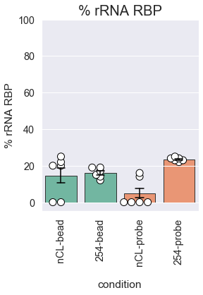

```python
#### Let's plot the percentage of identified RBP genes that are associated with rRNA
jvis.BarPlotByGroup_sbplot(metaStatsRibozero, x_col = 'condition', y_col = '% rRNA RBP', title = '% rRNA RBP', pal = set2_paired, yrange = [-5,100], xlabel = '\ncondition')
```

### Results: UNDERWHELMING

Well this doesn't seem all that wonderful. Is it possible that ~350 genes interact with the rRNA lifecycle but are yet to be described? yes.  
But it's a difficult argument to make. An alternative would be to filter our QuickGo records for genes that have proven experimental evidence of interaction and then investigate how many we have recovered.

## 20. Analyse GO memberships #3: rRNA-Binding by Experimental Evidence

**Functions**  
jwrangle.AnnotateDataFrameCtrls( )  
jinspect.MQ_getFrequencyBySample( )  
jweb.filterQuickGoDict( )

And the same approach as for one or a list of GO ID can be fine tuned for records that have been curated to spcific levels of evidence. GO records attempt to curate all references made to a protein (in QuickGo) and this includes varied forms of evidence from direct experimental evidence and high throughput evidence to computational predictions and literature references. The function **jweb.filterQuickGoDict( )** can be used to filter our records to those of a specific type.

```python
#### Let's filter our ribozero GO records by experimental evidence and then investigate how many we have recovered.
dict_ribozero_ExEv = jweb.filterQuickGoDict(dict_ribozero, evidence_code = 'Experimental')

#### Next, annotate the last version of our modified proteinGroups table
pGroup_ribozero_ExEv = jwrangle.AnnotateDataFrameCtrls(pGroup_Freq, dict_ribozero_ExEv, search_match = 'ENTREZGENE_gPro primary', dict_match = 'ENTREZGENE_gPro primary', none_col = 'GO_None')

#### Next find the counts for each GO ID being searched we will modify our metadata table in a fashion in the same way as for prptide and gene counting.
#### We'll use iBAQ for these counts but, given all intensities have previously been filtered by LFQ membership both 'Intensity' or 'LFQ intensity' would give the same result.
metaStatsRibozero_ExEv = jinspect.MQ_getFrequencyBySample(pGroup_ribozero_ExEv['ann_df'], metaStats, freqList = list(dict_ribozero.keys()) + ['GO_None'], measure = 'iBAQ')
metaStatsRibozero_ExEv

#### Now Calculate the % GO0003723 members per group
metaStatsRibozero_ExEv['% rRNA RBP'] = metaStatsRibozero_ExEv.apply(lambda row: round(100 - (100*row['GO_None']/row['LFQ intensity'])), axis = 1)

pd.set_option('display.max_columns', 500)
metaStatsRibozero_ExEv[metaStatsRibozero_ExEv['condition']=='254-probe']
```

|  | experiment | condition | replicate | sample | measure | MQgroups | Peptides | Intensity | iBAQ | LFQ intensity | GO0005761 | GO0005840 | GO0033750 | GO0042254 | GO0042255 | GO0043021 | GO0043022 | GO0061668 | GO0097177 | GO1990112 | GO_None | % rRNA RBP |
| --- | --- | --- | --- | --- | --- | --- | --- | --- | --- | --- | --- | --- | --- | --- | --- | --- | --- | --- | --- | --- | --- | --- |
| 18 | s48_rRNA1of10_Slot1-54_1_4211 | 254-probe | A | 254-probe_A | Intensity | probe | 2634.0 | 296 | 296 | 296 | 3 | 24 | 0 | 9 | 5 | 16 | 6 | 0 | 1 | 0 | 259 | 12 |
| 19 | s49_rRNA1of10_Slot1-53_1_4210 | 254-probe | B | 254-probe_B | Intensity | probe | 2777.0 | 376 | 376 | 376 | 7 | 38 | 1 | 12 | 5 | 18 | 8 | 0 | 1 | 0 | 320 | 15 |
| 20 | p3833_50_PCprobe_C_Slot1-10_1_4212 | 254-probe | C | 254-probe_C | Intensity | probe | 3642.0 | 422 | 422 | 422 | 4 | 32 | 2 | 17 | 6 | 22 | 9 | 0 | 1 | 0 | 365 | 14 |
| 21 | p3833_51_PCprobe_D_Slot1-11_1_4213 | 254-probe | D | 254-probe_D | Intensity | probe | 3771.0 | 440 | 440 | 440 | 4 | 33 | 2 | 18 | 6 | 23 | 8 | 0 | 1 | 0 | 380 | 14 |
| 22 | p3833_52_PCprobe_E_Slot1-12_1_4214 | 254-probe | E | 254-probe_E | Intensity | probe | 3253.0 | 353 | 353 | 353 | 4 | 30 | 2 | 13 | 5 | 19 | 8 | 0 | 1 | 0 | 303 | 14 |
| 23 | p3833_53_PCprobe_F_Slot1-13_1_4215 | 254-probe | F | 254-probe_F | Intensity | probe | 3421.0 | 404 | 404 | 404 | 5 | 37 | 2 | 15 | 5 | 20 | 8 | 0 | 1 | 0 | 345 | 15 |

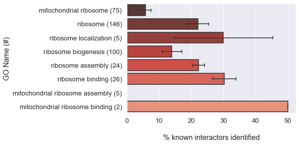

```python
#### First find the number of genes in each category and calculate the % of confirmed genes found
for key, value in dict_ribozero_ExEv.items():
    known = len(value['ENTREZGENE_gPro primary'].unique())
    if known > 0:
        metaStatsRibozero_ExEv['% ' + key + ' (' + str(known) + ')'] = metaStatsRibozero_ExEv.apply(lambda row: round(100*row[key]/known), axis = 1)

#### Relabel the GO IDs with names to make reading easier
MyGO_IDs = dict(zip([i.replace(':','') for i in MyGO_Stats_DF['go ID'].tolist()], MyGO_Stats_DF['GO Term']))
col_names = []
for i in list(metaStatsRibozero_ExEv.columns):
    if '% GO' in i:
        for key, value in MyGO_IDs.items():
            if key in i:
                col_names.append(i.replace(key, value))
    else:
        col_names.append(i)
metaStatsRibozero_ExEv.columns = col_names

#### Create Plot for our crosslinked probe samples only (other conditions are not worth doing)
plot = metaStatsRibozero_ExEv[metaStatsRibozero_ExEv['condition']=='254-probe'][['condition'] + [i for i in list(metaStatsRibozero_ExEv.columns) if 'ribosome' in i]]
ribozero_ExEvMelt = pd.melt(plot, "condition", var_name='GO Name (#)')
ribozero_ExEvMelt['GO Name (#)'] = ribozero_ExEvMelt['GO Name (#)'].apply(lambda x: x.replace('% ','')) # we'll remove the % from the names to reduce redundancy from our plot labels.

#### Plot values
bp_bar_edge = dict(linewidth=1.5)
bp_error_edge = dict(capsize=0.2, errcolor=".2", edgecolor=".2",errwidth=1.5)

sns.set(font_scale=1.2)
ax = sns.barplot(x='value', y='GO Name (#)', data=ribozero_ExEvMelt, palette='Reds_d', ci= 'sd', **bp_bar_edge, **bp_error_edge)
ax.set_xlabel('\n% known interactors identified')
```

### Results: NOT BAD!

Using membership counts to assess the coverage a method can deliver for a specific compartment of molecular function introduces several comprehension issues:  
a) Smaller categories can appear to be of less value than larger categories despite their membership being more restrictive  
b) Categories can vary in size based on their wider research popularity, and this will not reflect physiological importance  
c) Choosing highly permissive levels of evidence, such as computational predictions, clouds judgement of what baseline is achievable during the development of new methods.

Point b) can be addressed by assessing category representation with respect to background lists and Gene Ontology Enrichment Analyses (GOEA). Many online tools are available for doing this and so none are made native to this package. An example of their use can be found in the tutorial for Perturbation Analysis of Dyanmic RBP Networks.

## Conclusion

The targeted RBP-RNA method has the following positives:

- Probe first captures greatly outperform the bead capture
- Fewer RBP are discovered than for global and OdT captures. This suggests that some degree of exclusivity comes from the target hybridisation.
- Nearly all discovered RBP are RNA-Binding and the nCL samples are very clean.
- The ribozero kit depends on streptavidin-biotin links and these do not appear to be affected. This is positive news for the use of custom probes.
- The use of scrambled negative control probes and comparison between different biological conditions would aid in identifying important transcript interactors.

The targeted RBP-RNA method has the following negatives:

- No scrambled negative control was used in this experiment. It would be difficult to design one because the ribozero probes are of unknown sequence and length.
- Hybridisation in the presence of trace guanidine, phenol-chloroform, and a high % of formamide means that a thorough investigation of ideal binding temperature is required. This would imply a great deal of effort; ideally using sequencing.